# Voting Technology, Political Responsiveness, and Infant Health: Evidence From Brazil

Gustavo Henrique and Bruno Tonholo

2024-10-30

## 1 - Introduction

### Motivation

- Redistribution of resources is a key activity of the state, and its extent and form vary substantially worldwide.
- A government’s decision of how much to redistribute, and to whom, is embedded in a political system.
- There is a long tradition of theoretical work positing that elections determine the allocation of resources.
- A key prediction of these models is that increased political participation of poorer voters leads to more redistribution (toward them).
- The evidence on this, however, is mixed and puzzling.
- Focusing on improvements in participation within a context where universal suffrage is already established.

### Goals

- Show how improving the political participation of less educated (poorer) voters can advance policies targeting them.
- Estimate the effects of an electronic voting (EV) technology in increasing political participation and in the enfranchisement of less educated voters.
- Evaluate if this enfranchisement of the less educated citizenry did indeed affect policy in a manner consistent with political economy theories of redistribution.

### Institutional Background

- Federal legislation establishes the same election rules for all states. Legislators are elected under an open-list proportional representation with the entire state being a single multi-member district.
- Under open-list rule, a citizen casts a vote to an individual candidate, not a party list. The combination of large districts and voting for individual candidates makes voters face a large number of candidates, making listing names or illustrations in a ballot impractical. Moreover, state elections in Brazil are held jointly with federal elections for president, the federal senate, and the lower chamber of congress.
- Example: in the 1998 election, a voter in the state of São Paulo had to choose one candidate out of 1265 for the state legislature; 661 candidates for the lower chamber of federal congress; 10 candidates for state governor; 13 candidates for the federal senate; and 12 presidential candidates. This exemplifies the impossibility of simplified voting under paper ballots, as well as the overall complexity of voting.
- According to the 1991 Census (the last one prior to the introduction of electronic voting), 23% of adults were “unable to read or write a simple note.” Moreover, Brazilian paper ballots required citizens to write down their vote and involved only written instructions.

### Paper Ballots x EV

[figure not shown]

## 2 - Empirical Strategy

### Details

- The paper exploits a regression discontinuity design (RDD) embedded in EV’s introduction.
- In the 1994 only paper ballots where used. In the 1998 election, only municipalities with more than 40,500 registered voters used the new technology, while the rest used paper ballots. While in 2002, only EV was used.
- Such a schedule implies that the evolution of EV in a state is entirely determined by a time-invariant cross-sectional variable: the share of voters living in municipalities above the cutoff for its use in 1998. If a state has S% of its voters living above cutoff, S% of its voters changed from using paper to EV technology between the 1994 and 1998 elections. Moreover, between the 1998 and 2002 elections, the remaining (1−S)% of voters switched to EV. Hence, states with higher shares of voters above the 40,500-voter threshold should experience most of the enfranchising effects of EV earlier than the states with a low share.
- Intuitively, the empirical strategy tests if outcomes of interest track this same pattern. The effects of EV on policy outcomes are thus identified only from variation coming from the interaction of a cross-sectional variable (share of voters above the cutoff) with the timing of elections.
- Focus on health care spending, since it is an area that disproportionately affects the less educated. Poorer Brazilians rely mostly on a public-funded system for health care services, while richer voters are more likely to use private services. The less educated have thus relatively stronger preferences for public health services, and a shift in spending toward health care can be interpreted as redistribution to the poor.
- Prenatal visits and birthweight.
- The main identification assumption behind this empirical approach is that no omitted variable affecting the outcomes follows the particular pattern of electronic voting’s introduction.
- See if the timing of effects occurs quickly after elections, implying that possible omitted shocks (and their mean reversion) must follow quite specific timing.
- Check for (placebo) effects on variables not expected to be affected by EV, such as general economic conditions and birth outcomes for more educated mothers, as well as spending by municipal governments, which were exposed to EV under different timing but should also respond to shocks to health care demand.
- Focus on lagged and lead outcomes and, as we’ll see, finds that the share of voters above the cutoff is orthogonal to changes in outcomes in the periods when it is not associated with EV changes in voting technology, addressing issues of pre-trends.
- Re-estimate the effects with controls for possible (nonlinear) time trends interacted with state characteristics, to test the possibility that the results are not driven by another shock with heterogeneous effect across states.

### Estimated Equations

- Let $Si$ denote the share of voters in state $i$ that reside in municipalities above the cutoff in the 1998 election.
- Let $electro_{ie}$ denote the share of voters using EV in state $i$ at an election held at year $e$.
- $electro_{i1998} − electro_{i1994} = Si$.
- $electro_{i2002} − electro_{i1998} = 1 - Si$.
- Let $y_{ie}$ denote an outcome for state i at the legislative term elected at year e (e.g., $y_{i98}$ is the outcome observed during the 1999–2002 legislative term). We have:
- $\Delta y_{i98} = y_{i98} − y_{i94}$.
- $\Delta y_{i98} = \alpha_{98} + \theta_{98}S_i + \beta_{98}X_{i02} + \varepsilon_{i98}$.
- $\Delta y_{i02} = \alpha_{02} + \theta_{02}S_i + \beta_{02}X_{i02} + \varepsilon_{i02}$.
- $\theta^{98}$: measures the effect of $S_i$ on the change in average $y_{ie}$ between the 1995–1998 and 1999–2002 legislative terms.
- $\theta^{02}$: measures the effect of $1 - S_i$ on the change in average $y_{ie}$ between the 1999–2002 and 2003–2006 legislative terms.
- So, the author takes evidence that $\theta^{98} = -\theta^{02} \equiv \theta$ as an indication that $\theta$ measures the causal effect of EV.
- $y_{ie} = \alpha_e + \theta_{Si} \cdot Term_{e}^{98} + \gamma_i + \beta X_{ie} + \epsilon_{ie}$.

### Timeline

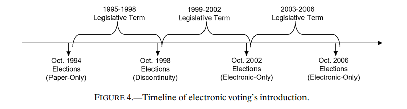

### Map

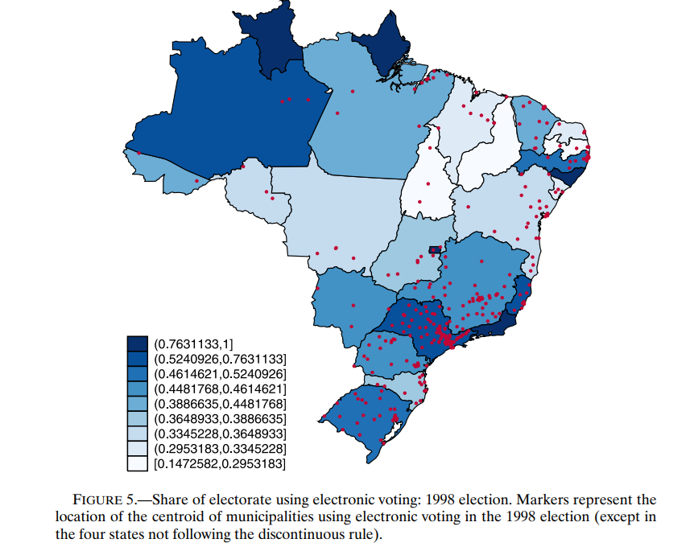

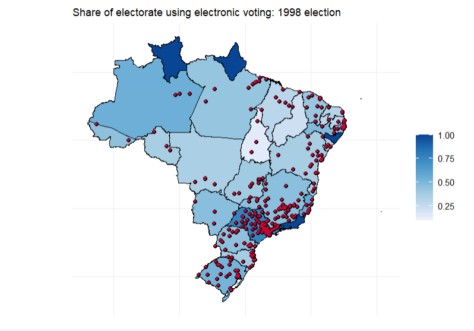

## 3 - Results

### Figures

#### Figure 2

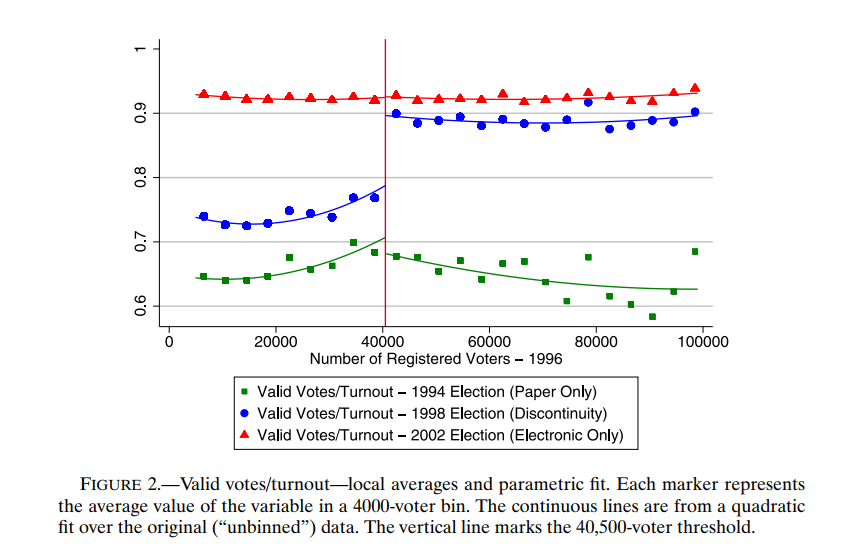

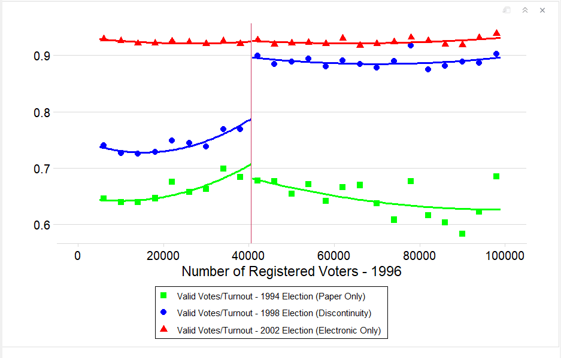

#### Figure 3

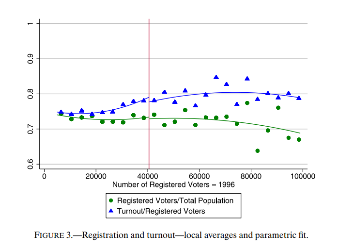

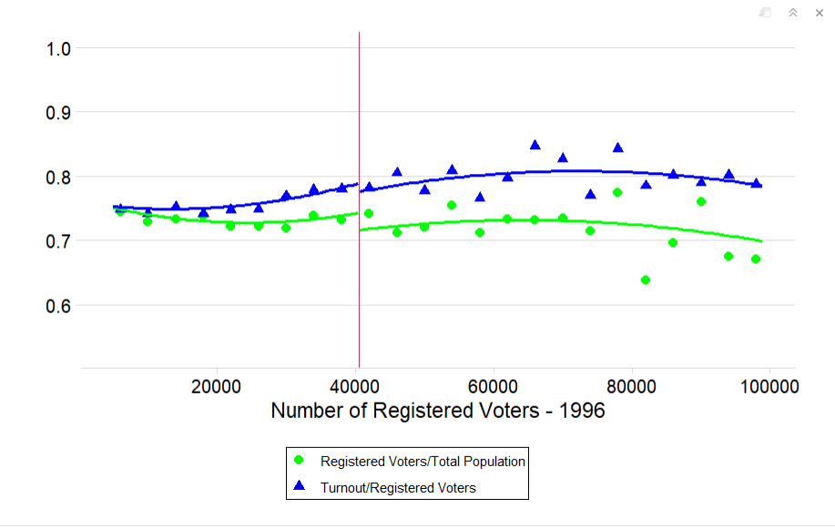

### Tables

#### Table 1

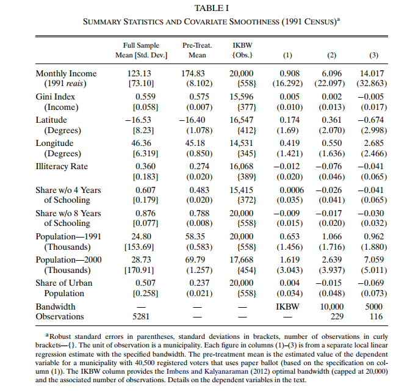

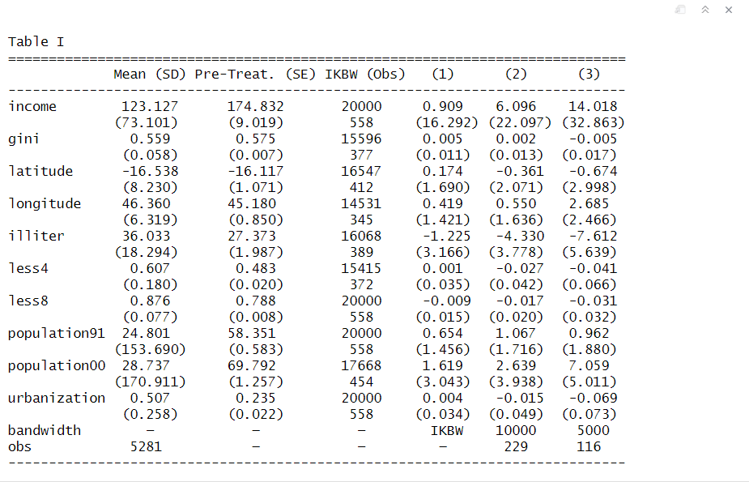

#### Table 2

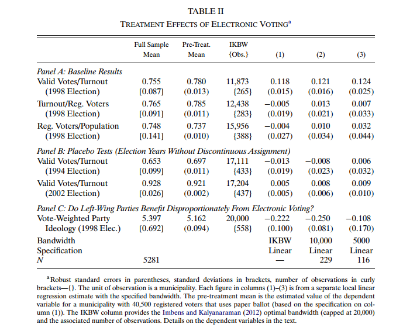

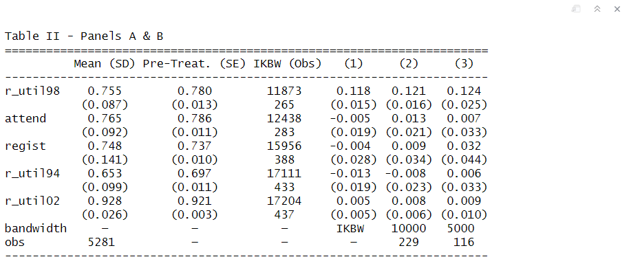

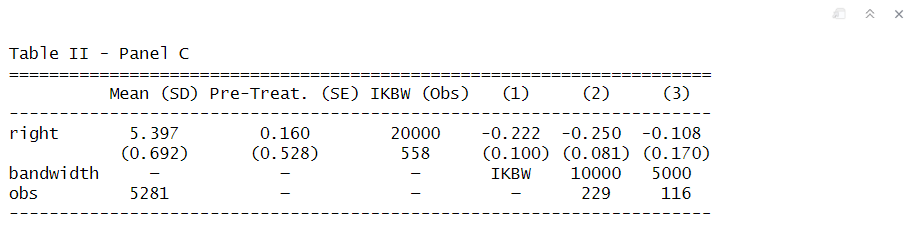

#### Table 3

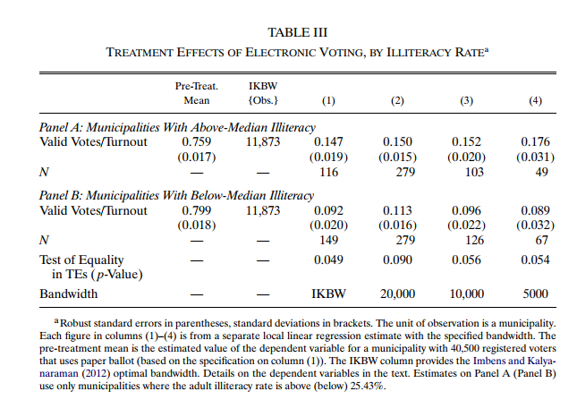

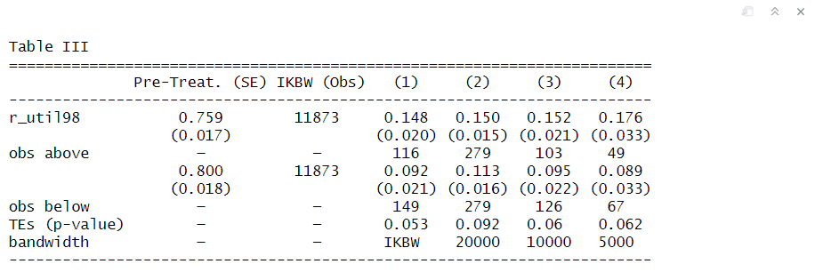

#### Table 4

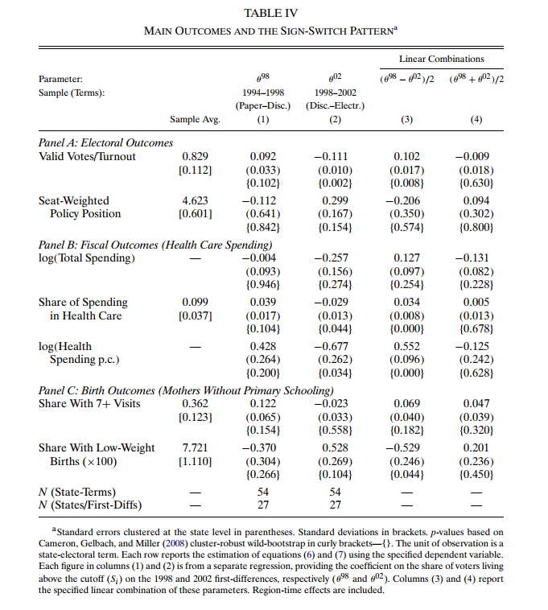

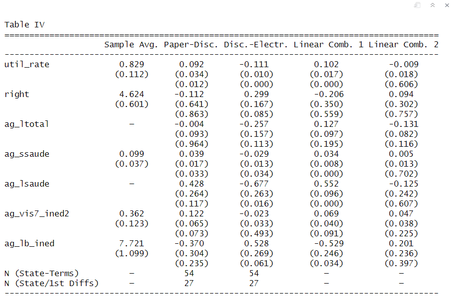

#### Table 5

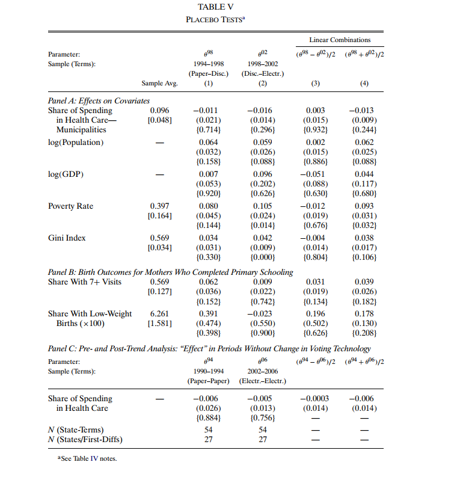

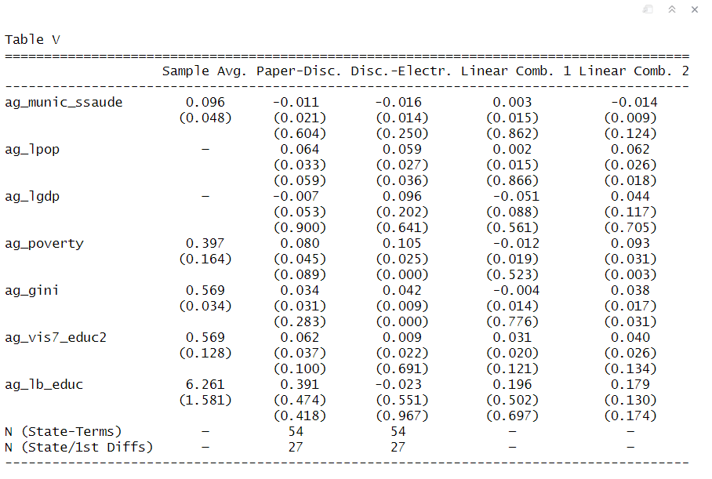

#### Table 6

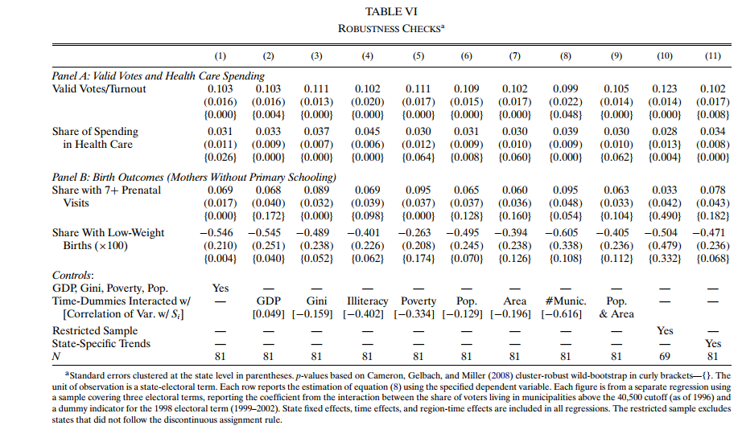

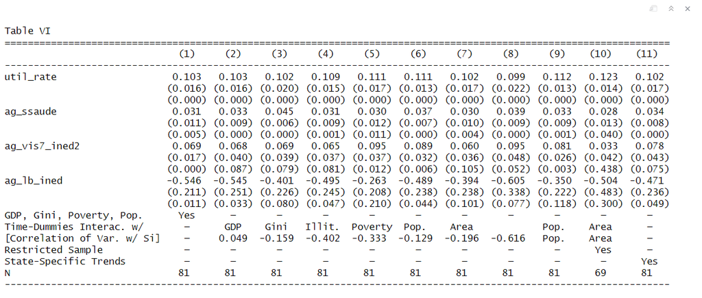

## 4 - Conclusion

- Results indicate that EV promoted the de facto enfranchisement of (mainly less educated) voters.
- Also showed consistency with the predictions of theories of redistributive politics and enfranchisement and democratization, since it increased government spending in a service that particularly benefits less educated voters: health care. It also had effects on its utilization and outcomes, increasing the number of prenatal visits and reducing the number of low-weight births by less educated mothers.
- A caveat is that the estimated effects may be dependent on the particular context. The degree of literacy required to operate the Brazilian paper ballots and the features of the Brazilian political and health care systems.
- However, it still shows how increasing the political participation of disadvantaged groups can shift policymaking and affect outcomes, and, most importantly, provides evidence supporting the general mechanisms in redistributive politics.